# Data Analysis

Tim Abramov

## Question 1

**“Are there any associations that can be observed between games that received a Metacritic score and those that didn’t?”**

Since the dataset I’m using consists of quite a few variables, I will compare only 4 variables to see if there are any associations between games that have a Metacritic score and those that don’t. I’ve decided to use number of owners, game price, number of recommendations, and achievement count as the variables I would like to test.

First of all, let’s divide our data in two groups by whether a game received or not a Metacritic score:

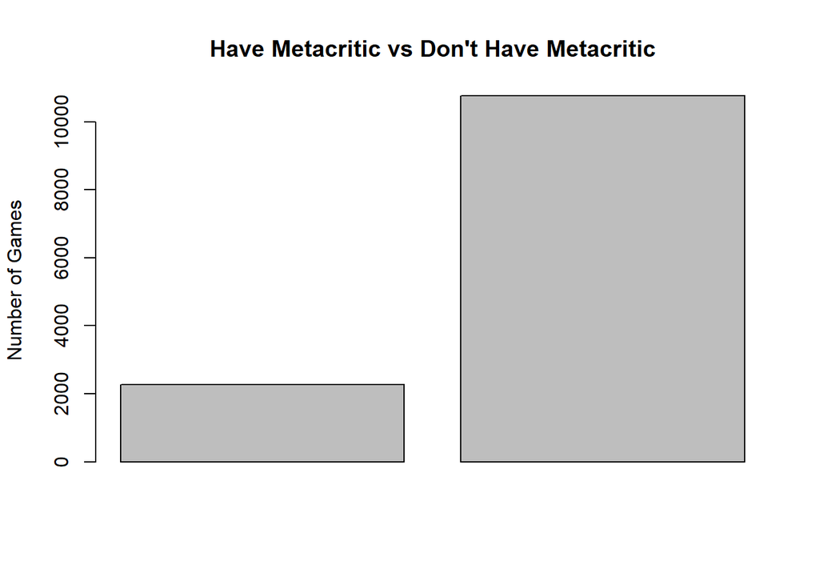

```r
with_metacritic <- filter(games, Metacritic > 0)
without_metacritic <- filter(games, Metacritic == 0)

meta_nonmeta <- c(length(with_metacritic$QueryID), length(without_metacritic$QueryID))
barplot(meta_nonmeta, main = "Have Metacritic vs Don't Have Metacritic", ylab = "Number of Games")
```

As you can see - majority of games didn’t receive a Metacritic score. Only about 17% of games received it.

Now, let’s look at the means for our selected variables. My prediction is that there are some distinct differences in values for those variables between the two groups. First, I tried to use a boxplot but it’s too hard to interpret the plot due to big numbers + many outliers:

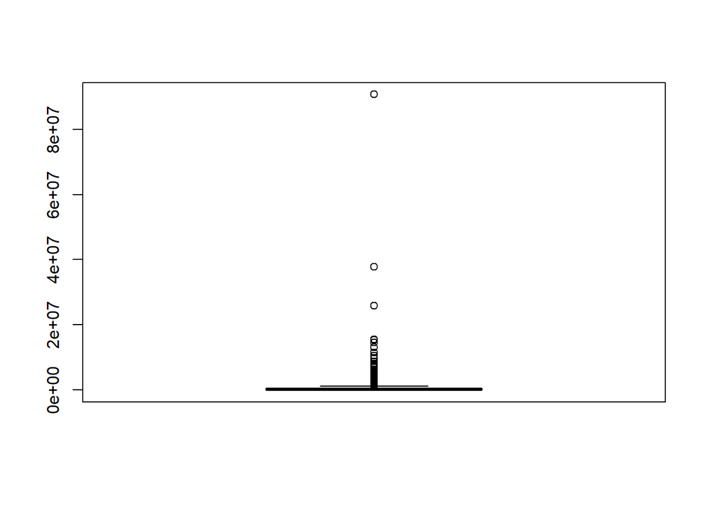

```r
boxplot(with_metacritic$SteamSpyOwners)
```

Thus, I decided to use text-based statistical summaries to observe any differences between our groups:

```
## [1] "SteamSpyOwners(with Metacritic first):"
```

```
##     Min.  1st Qu.   Median     Mean  3rd Qu.     Max.
##        0    36049   134692   601802   481105 90687580
```

```
##     Min.  1st Qu.   Median     Mean  3rd Qu.     Max.
##        0      533     5739    78921    27620 27025292
```

```
## [1] "PriceFinal:"
```

```
##    Min. 1st Qu.  Median    Mean 3rd Qu.    Max.
##    0.00    8.99    9.99   14.00   19.99   99.99
```

```
##    Min. 1st Qu.  Median    Mean 3rd Qu.    Max.
##   0.000   0.990   4.990   6.885   9.990 234.990
```

```
## [1] "RecommendationCount:"
```

```
##      Min.   1st Qu.    Median      Mean   3rd Qu.      Max.
##       0.0     138.2     529.5    4630.5    2186.8 1427633.0
```

```
##     Min.  1st Qu.   Median     Mean  3rd Qu.     Max.
##      0.0      0.0      0.0    482.5    124.0 237684.0
```

```
## [1] "AchievementCount:"
```

```
##    Min. 1st Qu.  Median    Mean 3rd Qu.    Max.
##    0.00    0.00   14.50   26.51   39.00 1448.00
```

```
##    Min. 1st Qu.  Median    Mean 3rd Qu.    Max.
##    0.00    0.00    0.00   12.29   16.00 1629.00
```

So, let’s start with SteamSpyOwners: mean number of owners for games with Metacritic score is quite a bit higher than the other group. Also, 3rd quartile numbers for both groups are smaller than the means, indicating that there are quite a few outliers affecting the average drastically.

For price: mean statistic is about twice as big in group with Metacritic score compared to one without.

RecommendationCount: mean number of recommendations for the group with the score is quite a bit bigger comparatively and median for group without Metacritic is 0, which means that at least 50% of game in that group don’t even have a single recommendation.

In terms of number of achievements, at least 50% of games in group without the score don’t have any. Also mean is about twice as big for the group that has the Metacritic score. Pretty amazed to see the max numbers of achievements, those games are either pretty deep or “grindy”(when developer forces you to progress really slowly, usually with an option to pay to progress quicker…)

Let’s also look on density plots for those variables, to hopefully have some new perspectives on the data:

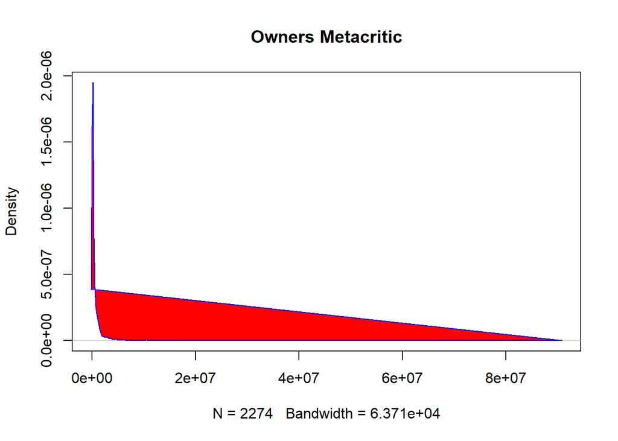

```r
#Kernel Density plots for the variables
d1 <- density(with_metacritic$SteamSpyOwners)
plot(d1, main = "Owners Metacritic")
polygon(d1, col="red", border = "blue")
```

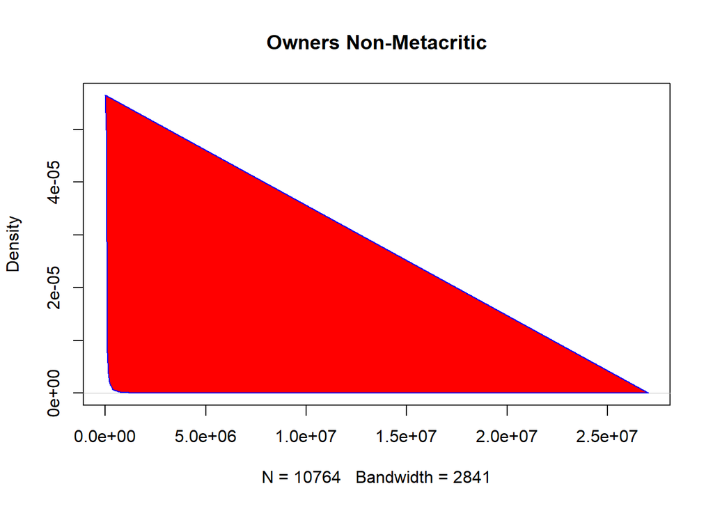

```r
d1 <- density(without_metacritic$SteamSpyOwners)
plot(d1, main = "Owners Non-Metacritic")
polygon(d1, col="red", border = "blue")
```

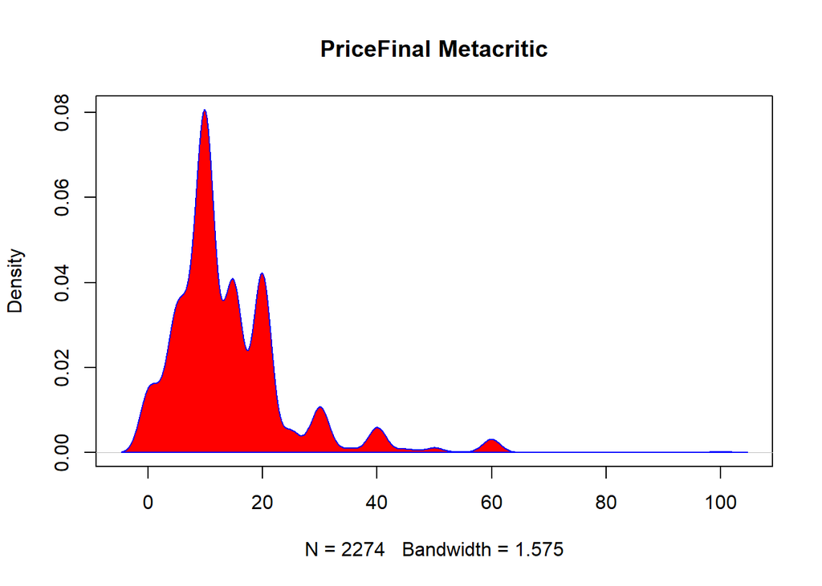

```r
d1 <- density(with_metacritic$PriceFinal)
plot(d1, main = "PriceFinal Metacritic")
polygon(d1, col="red", border = "blue")
```

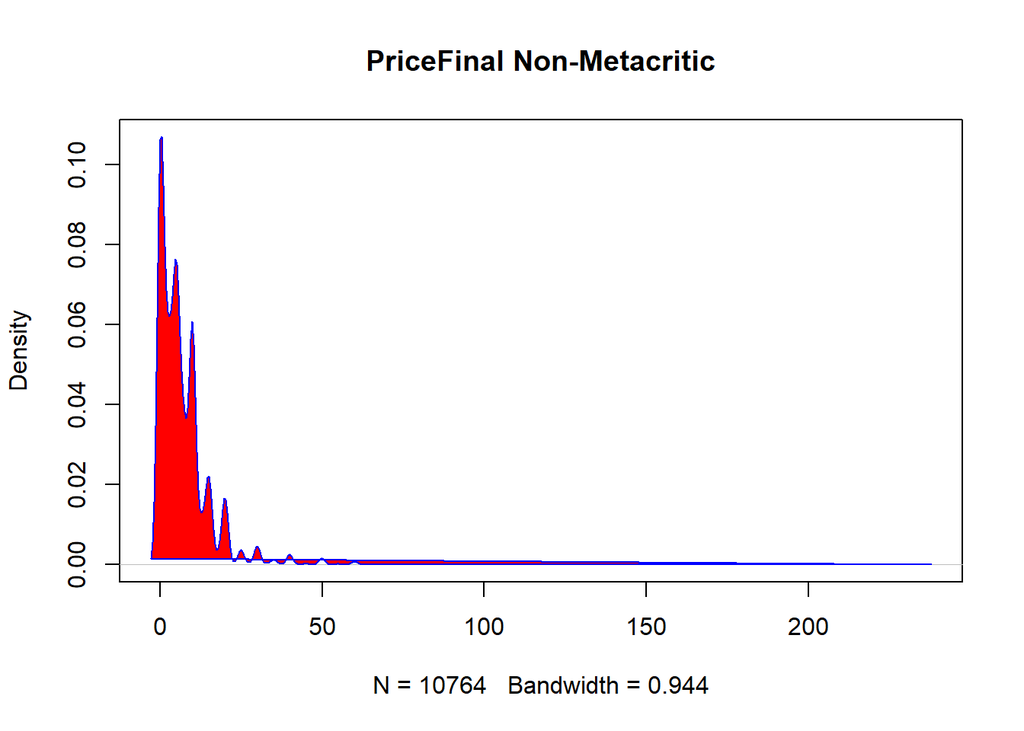

```r
d1 <- density(without_metacritic$PriceFinal)
plot(d1, main = "PriceFinal Non-Metacritic")
polygon(d1, col="red", border = "blue")
```

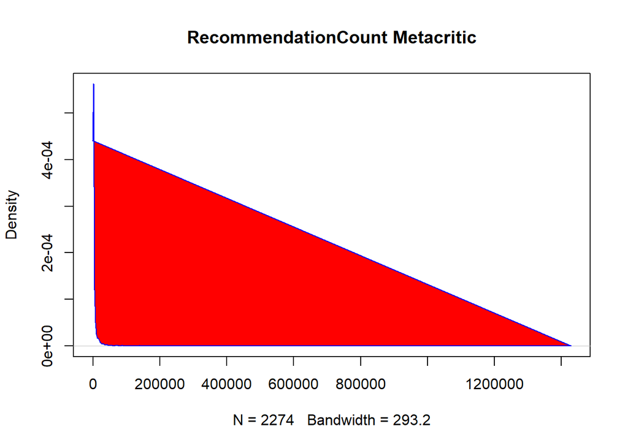

```r
d1 <- density(with_metacritic$RecommendationCount)
plot(d1, main = "RecommendationCount Metacritic")
polygon(d1, col="red", border = "blue")
```

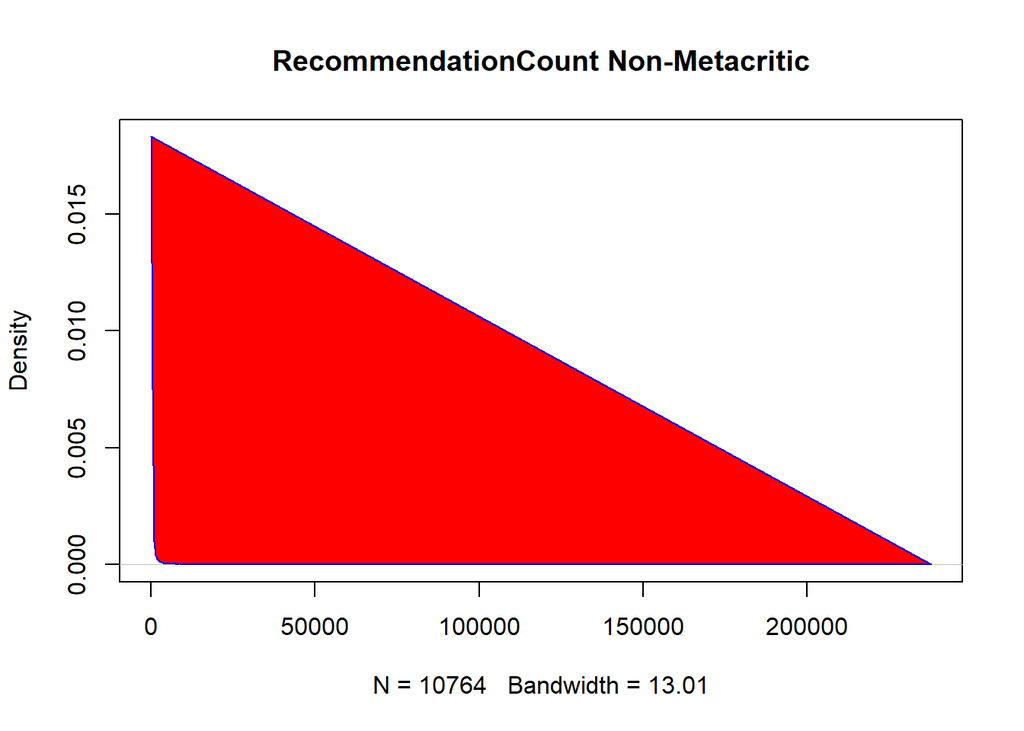

```r
d1 <- density(without_metacritic$RecommendationCount)
plot(d1, main = "RecommendationCount Non-Metacritic")
polygon(d1, col="red", border = "blue")
```

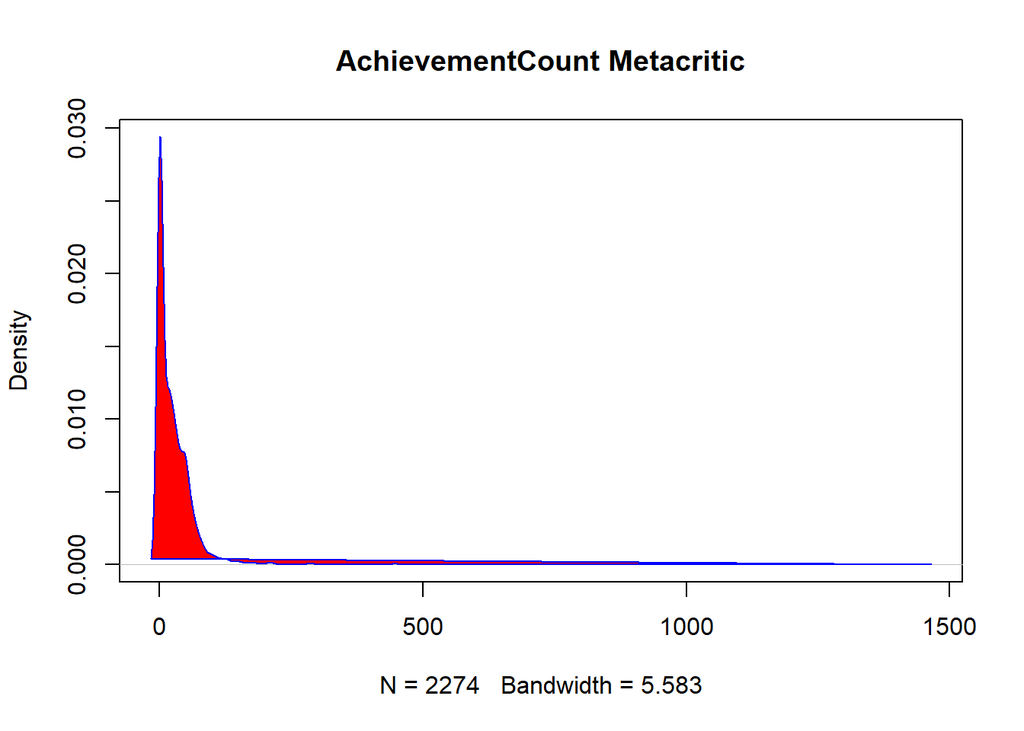

```r
d1 <- density(with_metacritic$AchievementCount)
plot(d1, main = "AchievementCount Metacritic")
polygon(d1, col="red", border = "blue")
```

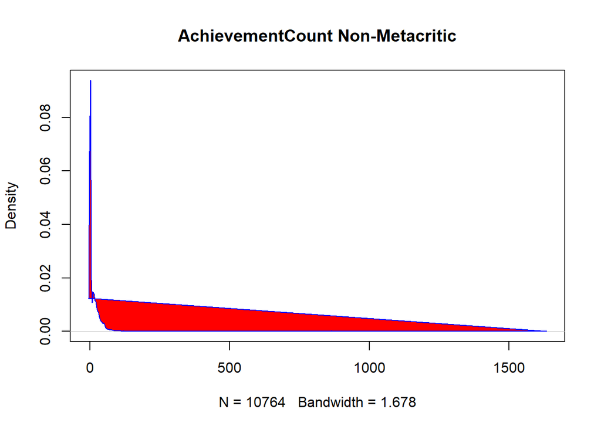

```r
d1 <- density(without_metacritic$AchievementCount)
plot(d1, main = "AchievementCount Non-Metacritic")
polygon(d1, col="red", border = "blue")
```

Hmm, well, these graphs didn’t really reveal anything new to me, but still nice to have a visual representation of what’s going on with the variables.

In conclusion to this question, there are certanly some distinct differences between games that have a Metacritic score and those that don’t, in terms of their sales, price, recommendations count, and achievements count. This does support my prediction made earlier.

## Question 2

**“Is there an association between number of screenshots in game description and the sales of the game?”**

To visualize the relationship, let’s graph a scatterplot first:

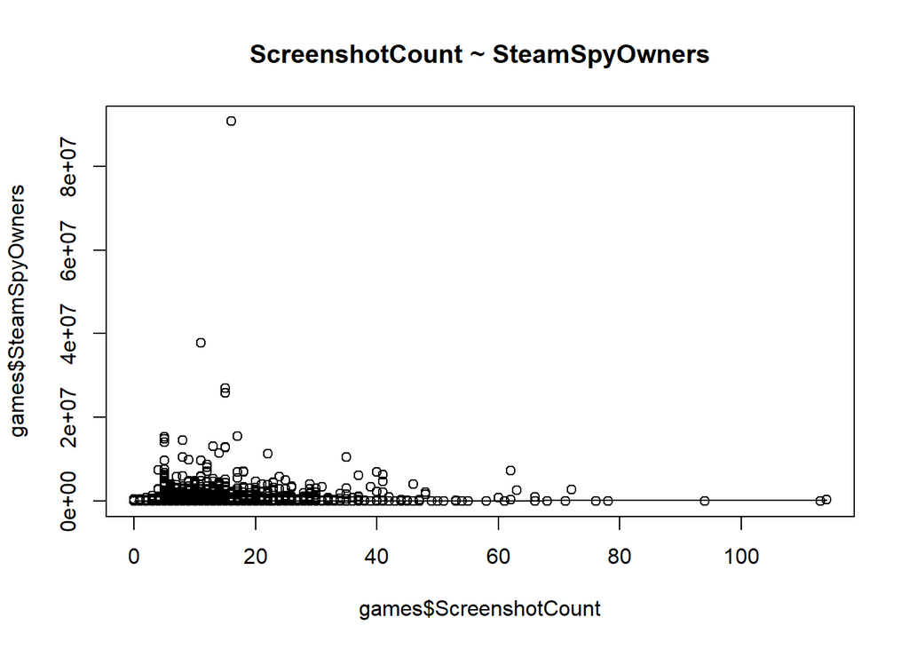

Not much can be seen at that scale, too many outliers.

Speaking of which, to see if we have any outliers (and how many), let’s graph boxplots for both the “ScreenshotCount” and “SteamSpyOwners”:

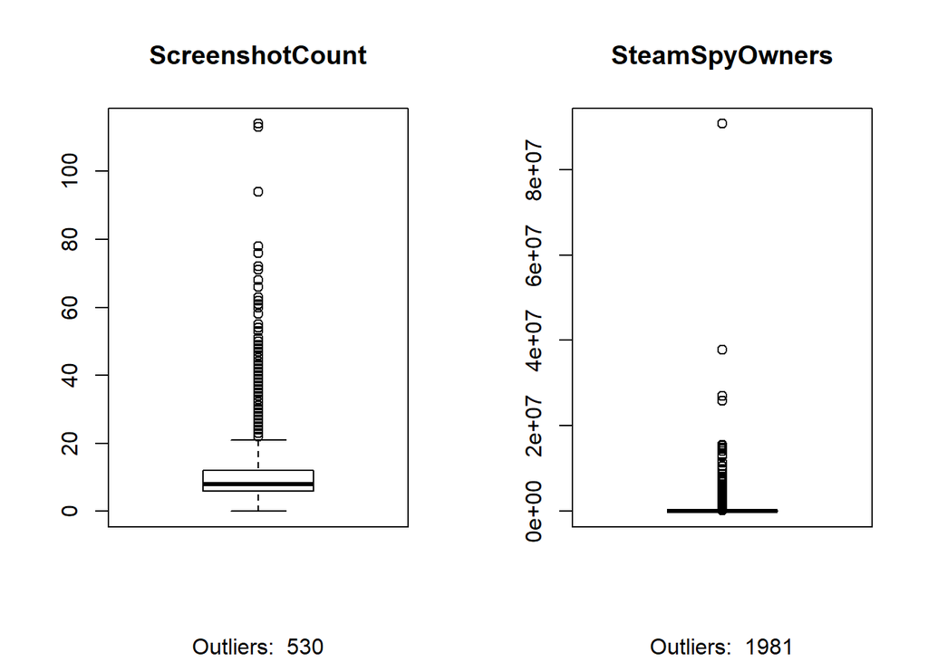

As you can see, we have quite a few outliers. 530(around 4% of the dataset) for number of screenshots for a game, and 1981 (around 15% of the dataset) for number of owners for a game! To proceed with linear regression, we will need to deal with those outliers.

I won’t be getting rid of outliers, since they were collected the same way all the other data was collected (they’re not a mistake) and are significant for the question(s) I want to answer. To help linearize the relationships between the variables, I will transform the data needed into either log or square root of it. Let’s see which will work the best.

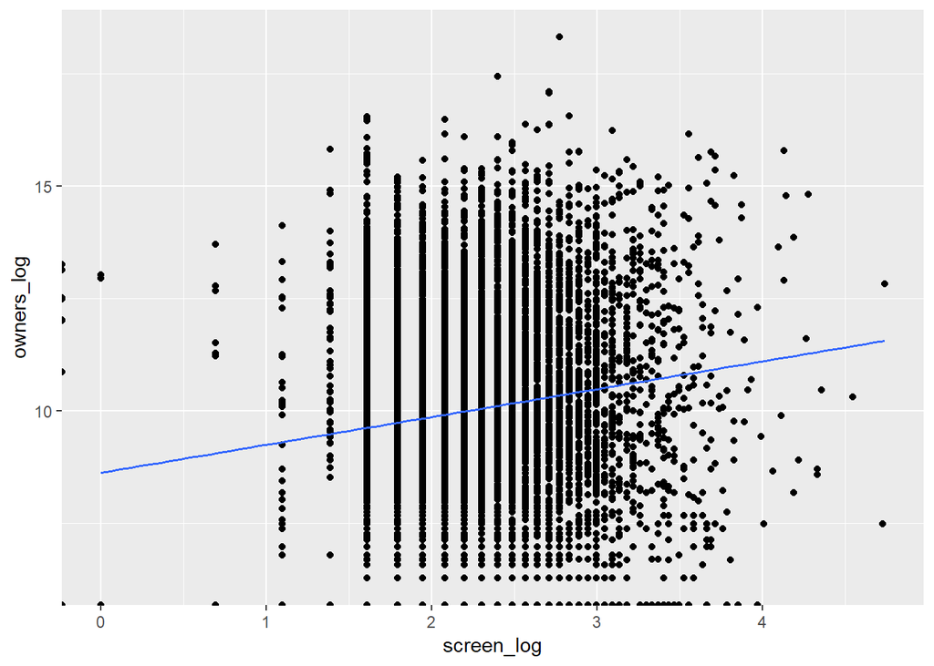

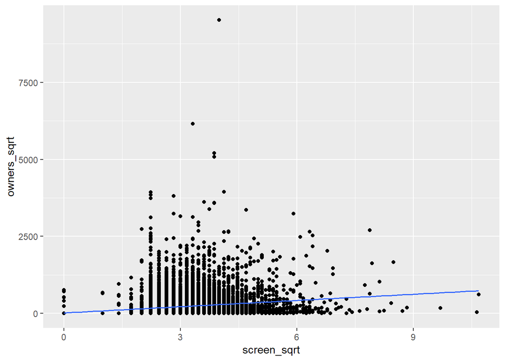

While it’s still not easy to see, but there appears to be linear relationship between our variables. Due to the nature of how log works, when I “logged” my variables, records with zeroes in them were removed. Since zero values do matter to us (free games or games without screenshots), I decided to proceed with using square roots of our variables.

To use linear regression on our variables, there are a 4 main assumptions we need to verify: 1.Is it indeed a linear relationship between the variables? 2.Are the residuals normally distributed? 3.Is there constant variance around the regression line at each x-location? 4.Is the data independent (random)?

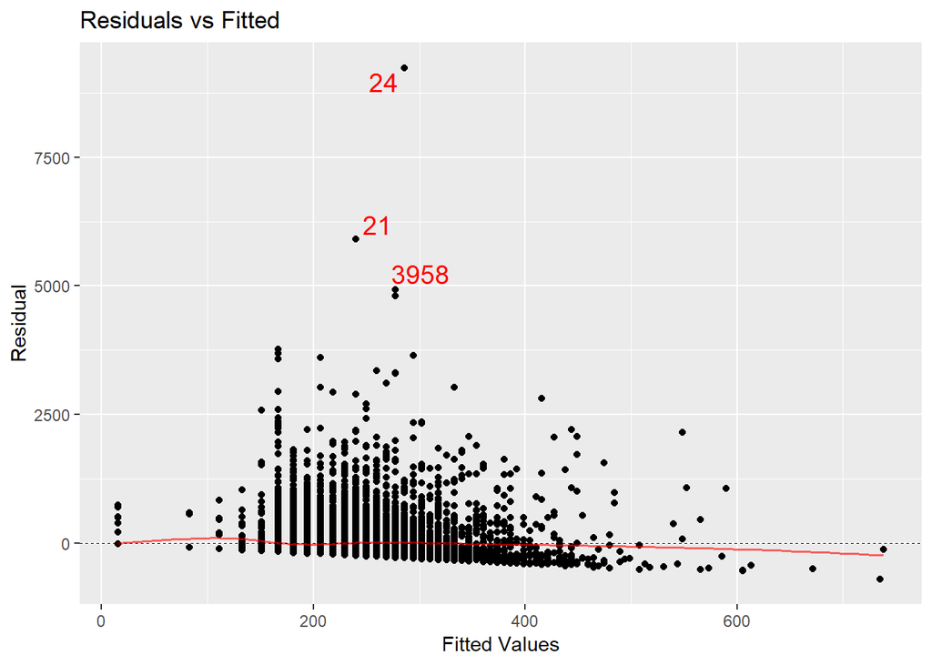

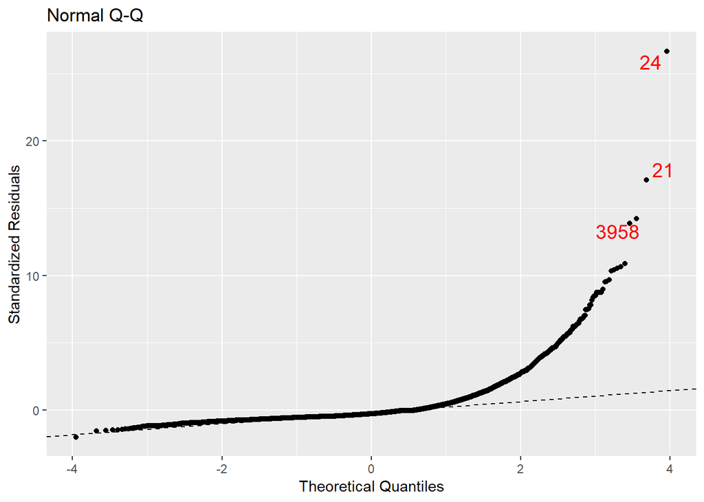

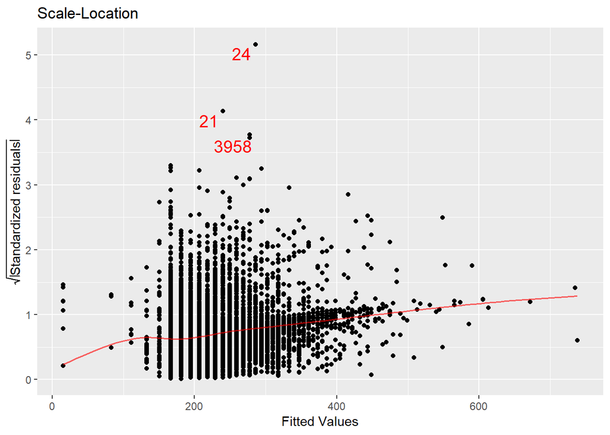

From the “Residuals vs Fitted” plot we can see that it’s indeed a linear relationship, since the red line is mostly horizontal. In terms of normality of residual distribution, from “Normal Q-Q” plot we can see that it’s not the case. Also, from “Scale-Location” plot we can observe that there doesn’t exist a constant variance around the regression line at each x-location. Since each and every game is a unique thing and and parameters of one game usually doesn’t depend on parameters from the other game, I will assume that our data is independent. As we can see, our data fails 2 out of 4 assumptions: normality of residual distribution and a constant variance around the regression line. Because of that regression analysis is not the ideal tool to assess the assosiation between those variables. But since it’s the best way to do it that I know, I will procede with it, just need to keep in mind those failed assumptions:

```r
cor(owners_sqrt ~ screen_sqrt, data = games)
```

```
## [1] 0.2015076
```

```r
summary(screen_fit_sqrt)
```

```
##
## Call:
## lm(formula = owners_sqrt ~ screen_sqrt, data = games)
##
## Residuals:
##    Min     1Q Median     3Q    Max
## -692.7 -166.7  -96.0   25.5 9236.9
##
## Coefficients:
##             Estimate Std. Error t value Pr(>|t|)
## (Intercept)   15.239      8.923   1.708   0.0877 .
## screen_sqrt   67.715      2.883  23.489   <2e-16 ***
## ---
## Signif. codes:  0 '***' 0.001 '**' 0.01 '*' 0.05 '.' 0.1 ' ' 1
##
## Residual standard error: 346.4 on 13036 degrees of freedom
## Multiple R-squared:  0.04061,    Adjusted R-squared:  0.04053
## F-statistic: 551.7 on 1 and 13036 DF,  p-value: < 2.2e-16
```

Firstly, checking correlation between variables - it’s pretty low. By running a summary analysis of our regression line we can derive our linear regression formula: y = 15.239 + 67.715 * x owners = 15.239 + 67.715 * screenshots

Using a linear regression model for this data (square root of it) have proven to be not the best approach: it failed 2 out 4 assumptions to use linear model and does have really weak corellation using this model.

## Question 3

**“Is there an association between how many copies of the game were sold and the price of the game?”**

To visualize the relationship, let’s graph a scatterplot first:

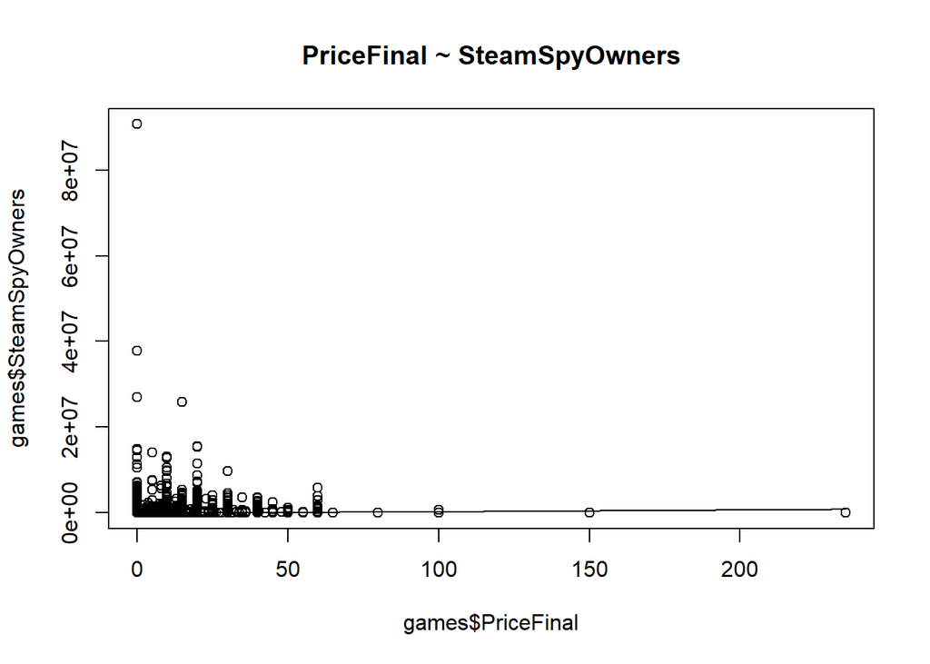

As with previous question, can’t really say much at this stage. Again, problems with outliers

Let’s graph boxplots for both the “PriceFinal” and “SteamSpyOwners”:

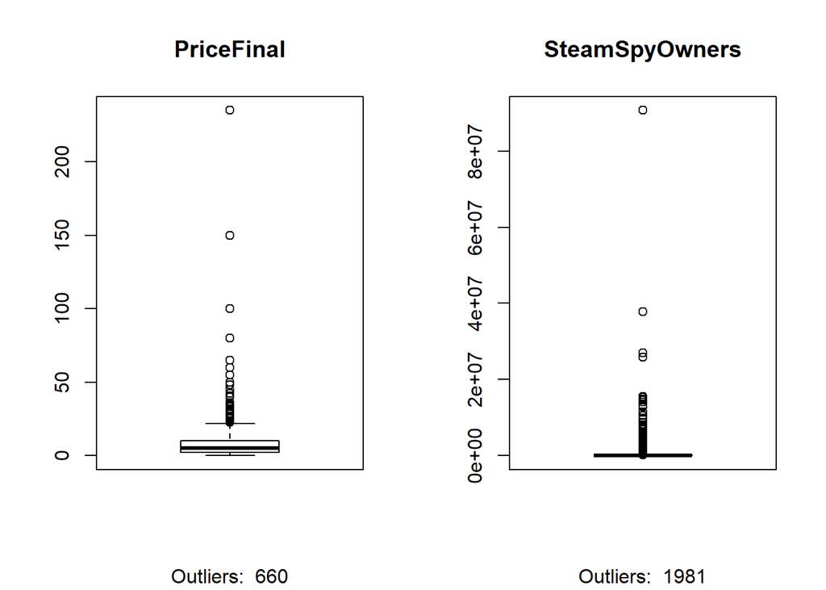

Number of outlier is similar to previous question. 660(around 5% of the dataset) for final price for a game, and 1981 (around 15% of the dataset) for number of owners! What is pretty interesting, is that most games are bellow $25 mark, which makes sense, just never thought of it before. Before we move on to the next stage, something needs to be done about those outliers.

Since in question (2) we determined that values of 0 do matter to us, we will try to square root our data to help linearize the relationship between final price of the game and it’s owner count:

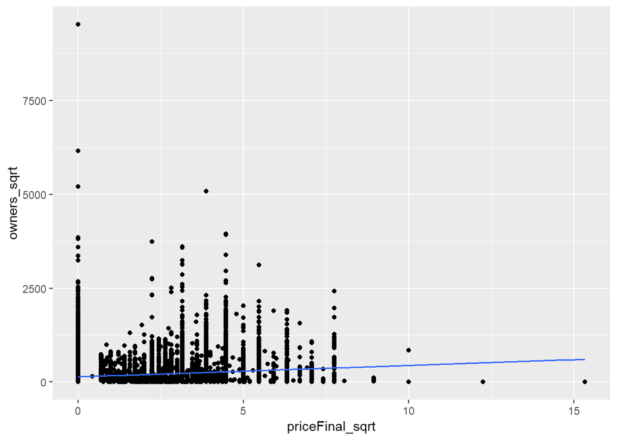

```r
##creating sqrt
games$priceFinal_sqrt <- sqrt(games$PriceFinal)
##scatter plot
gf_point(owners_sqrt ~ priceFinal_sqrt, data = games) %>% gf_lm()
```

Linear relationship is basically impossible to spot at this point.

Let’s check our assumptions for using a linear model: 1.Is it indeed a linear relationship between the variables? 2.Are the residuals normally distributed? 3.Is there constant variance around the regression line at each x-location? 4.Is the data independent (random)?

[figure not shown]

[figure not shown]

[figure not shown]

```r
cor(games$SteamSpyOwners, games$PriceFinal)
```

```
## [1] 0.05149432
```

```r
summary(priceFinal_fit_sqrt)
```

```
##
## Call:
## lm(formula = owners_sqrt ~ priceFinal_sqrt, data = games)
##
## Residuals:
##    Min     1Q Median     3Q    Max
## -608.7 -166.2 -113.5   32.9 9382.7
##
## Coefficients:
##                 Estimate Std. Error t value Pr(>|t|)
## (Intercept)      140.307      5.458   25.70   <2e-16 ***
## priceFinal_sqrt   30.555      1.915   15.96   <2e-16 ***
## ---
## Signif. codes:  0 '***' 0.001 '**' 0.01 '*' 0.05 '.' 0.1 ' ' 1
##
## Residual standard error: 350.2 on 13036 degrees of freedom
## Multiple R-squared:  0.01916,    Adjusted R-squared:  0.01908
## F-statistic: 254.7 on 1 and 13036 DF,  p-value: < 2.2e-16
```

Similar to question (2) using linear regression for this data (square root of it) is a bad fit, especially this time - correlation is basically non-existent. Unfortunately this is the best model for the situation I know at the moment, most likely there are better ways to assess this question.